# Group 2 Assignment 2

```r
library(caret)
library(e1071)
```

## Task 1

Reading in the CSV file and looking at the head of the dataset.

```r
churn_data <- read.csv("BankChurners.csv", sep=",", header = TRUE)
head(churn_data)
```

|  | CLIENTNUM | Attrition_Flag | Customer_Age | Gender | Dependent_count | Education_Level | Marital_Status | Income_Category | Card_Category | Months_on_book | Total_Relationship_Count | Months_Inactive_12_mon | Contacts_Count_12_mon | Credit_Limit | Total_Revolving_Bal | Avg_Open_To_Buy | Total_Amt_Chng_Q4_Q1 | Total_Trans_Amt | Total_Trans_Ct | Total_Ct_Chng_Q4_Q1 | Avg_Utilization_Ratio | Naive_Bayes_Classifier_Attrition_Flag_Card_Category_Contacts_Count_12_mon_Dependent_count_Education_Level_Months_Inactive_12_mon_1 | Naive_Bayes_Classifier_Attrition_Flag_Card_Category_Contacts_Count_12_mon_Dependent_count_Education_Level_Months_Inactive_12_mon_2 |
| --- | --- | --- | --- | --- | --- | --- | --- | --- | --- | --- | --- | --- | --- | --- | --- | --- | --- | --- | --- | --- | --- | --- | --- |
| 1 | 768805383 | Existing Customer | 45 | M | 3 | High School | Married | $60K - $80K | Blue | 39 | 5 | 1 | 3 | 12691 | 777 | 11914 | 1.335 | 1144 | 42 | 1.625 | 0.061 | 9.3448e-05 | 0.99991 |
| 2 | 818770008 | Existing Customer | 49 | F | 5 | Graduate | Single | Less than $40K | Blue | 44 | 6 | 1 | 2 | 8256 | 864 | 7392 | 1.541 | 1291 | 33 | 3.714 | 0.105 | 5.6861e-05 | 0.99994 |
| 3 | 713982108 | Existing Customer | 51 | M | 3 | Graduate | Married | $80K - $120K | Blue | 36 | 4 | 1 | 0 | 3418 | 0 | 3418 | 2.594 | 1887 | 20 | 2.333 | 0.000 | 2.1081e-05 | 0.99998 |
| 4 | 769911858 | Existing Customer | 40 | F | 4 | High School | Unknown | Less than $40K | Blue | 34 | 3 | 4 | 1 | 3313 | 2517 | 796 | 1.405 | 1171 | 20 | 2.333 | 0.760 | 1.3366e-04 | 0.99987 |
| 5 | 709106358 | Existing Customer | 40 | M | 3 | Uneducated | Married | $60K - $80K | Blue | 21 | 5 | 1 | 0 | 4716 | 0 | 4716 | 2.175 | 816 | 28 | 2.500 | 0.000 | 2.1676e-05 | 0.99998 |
| 6 | 713061558 | Existing Customer | 44 | M | 2 | Graduate | Married | $40K - $60K | Blue | 36 | 3 | 1 | 2 | 4010 | 1247 | 2763 | 1.376 | 1088 | 24 | 0.846 | 0.311 | 5.5077e-05 | 0.99994 |

We eliminated the variables which are not helpful for the analysis:

```r
churn_data <- subset(churn_data, select = -c(1,22, 23))
head(churn_data)
```

|  | Attrition_Flag | Customer_Age | Gender | Dependent_count | Education_Level | Marital_Status | Income_Category | Card_Category | Months_on_book | Total_Relationship_Count | Months_Inactive_12_mon | Contacts_Count_12_mon | Credit_Limit | Total_Revolving_Bal | Avg_Open_To_Buy | Total_Amt_Chng_Q4_Q1 | Total_Trans_Amt | Total_Trans_Ct | Total_Ct_Chng_Q4_Q1 | Avg_Utilization_Ratio |
| --- | --- | --- | --- | --- | --- | --- | --- | --- | --- | --- | --- | --- | --- | --- | --- | --- | --- | --- | --- | --- |
| 1 | Existing Customer | 45 | M | 3 | High School | Married | $60K - $80K | Blue | 39 | 5 | 1 | 3 | 12691 | 777 | 11914 | 1.335 | 1144 | 42 | 1.625 | 0.061 |
| 2 | Existing Customer | 49 | F | 5 | Graduate | Single | Less than $40K | Blue | 44 | 6 | 1 | 2 | 8256 | 864 | 7392 | 1.541 | 1291 | 33 | 3.714 | 0.105 |
| 3 | Existing Customer | 51 | M | 3 | Graduate | Married | $80K - $120K | Blue | 36 | 4 | 1 | 0 | 3418 | 0 | 3418 | 2.594 | 1887 | 20 | 2.333 | 0.000 |
| 4 | Existing Customer | 40 | F | 4 | High School | Unknown | Less than $40K | Blue | 34 | 3 | 4 | 1 | 3313 | 2517 | 796 | 1.405 | 1171 | 20 | 2.333 | 0.760 |
| 5 | Existing Customer | 40 | M | 3 | Uneducated | Married | $60K - $80K | Blue | 21 | 5 | 1 | 0 | 4716 | 0 | 4716 | 2.175 | 816 | 28 | 2.500 | 0.000 |
| 6 | Existing Customer | 44 | M | 2 | Graduate | Married | $40K - $60K | Blue | 36 | 3 | 1 | 2 | 4010 | 1247 | 2763 | 1.376 | 1088 | 24 | 0.846 | 0.311 |

Looking at the structure of the dataset. There are several numerical and categorial variables.

```r
str(churn_data)
```

```
## 'data.frame':    10127 obs. of  20 variables:
##  $ Attrition_Flag          : chr  "Existing Customer" "Existing Customer" "Existing Customer" "Existing Customer" ...
##  $ Customer_Age            : int  45 49 51 40 40 44 51 32 37 48 ...
##  $ Gender                  : chr  "M" "F" "M" "F" ...
##  $ Dependent_count         : int  3 5 3 4 3 2 4 0 3 2 ...
##  $ Education_Level         : chr  "High School" "Graduate" "Graduate" "High School" ...
##  $ Marital_Status          : chr  "Married" "Single" "Married" "Unknown" ...
##  $ Income_Category         : chr  "$60K - $80K" "Less than $40K" "$80K - $120K" "Less than $40K" ...
##  $ Card_Category           : chr  "Blue" "Blue" "Blue" "Blue" ...
##  $ Months_on_book          : int  39 44 36 34 21 36 46 27 36 36 ...
##  $ Total_Relationship_Count: int  5 6 4 3 5 3 6 2 5 6 ...
##  $ Months_Inactive_12_mon  : int  1 1 1 4 1 1 1 2 2 3 ...
##  $ Contacts_Count_12_mon   : int  3 2 0 1 0 2 3 2 0 3 ...
##  $ Credit_Limit            : num  12691 8256 3418 3313 4716 ...
##  $ Total_Revolving_Bal     : int  777 864 0 2517 0 1247 2264 1396 2517 1677 ...
##  $ Avg_Open_To_Buy         : num  11914 7392 3418 796 4716 ...
##  $ Total_Amt_Chng_Q4_Q1    : num  1.33 1.54 2.59 1.41 2.17 ...
##  $ Total_Trans_Amt         : int  1144 1291 1887 1171 816 1088 1330 1538 1350 1441 ...
##  $ Total_Trans_Ct          : int  42 33 20 20 28 24 31 36 24 32 ...
##  $ Total_Ct_Chng_Q4_Q1     : num  1.62 3.71 2.33 2.33 2.5 ...
##  $ Avg_Utilization_Ratio   : num  0.061 0.105 0 0.76 0 0.311 0.066 0.048 0.113 0.144 ...
```

We are turning categorical variables into factors and leveled the intuitive factors.

```r
churn_data$Attrition_Flag <- factor(churn_data$Attrition_Flag, levels = c("Existing Customer", "Attrited Customer"))
churn_data$Income_Category <- factor(churn_data$Income_Category, levels = c("Less than $40K", "$40K - $60K", "$60K - $80K", "$80K - $120K", "$120K +", "Unknown"))
churn_data$Card_Category <- factor(churn_data$Card_Category, levels = c("Blue", "Silver", "Gold", "Platinum"))
churn_data$Education_Level <- factor(churn_data$Education_Level, levels = c("Uneducated", "High School", "College", "Graduate", "Post-Graduate", "Doctorate", "Unknown"))
churn_data$Marital_Status <- factor(churn_data$Marital_Status, levels = c("Single", "Married", "Divorced", "Unknown"))
churn_data$Gender <- factor(churn_data$Gender)
```

From the summary, we can extract that 16.07% of customers left the bank.

```r
summary(churn_data)
```

```
##            Attrition_Flag  Customer_Age   Gender   Dependent_count
##  Existing Customer:8500   Min.   :26.00   F:5358   Min.   :0.000
##  Attrited Customer:1627   1st Qu.:41.00   M:4769   1st Qu.:1.000
##                           Median :46.00            Median :2.000
##                           Mean   :46.33            Mean   :2.346
##                           3rd Qu.:52.00            3rd Qu.:3.000
##                           Max.   :73.00            Max.   :5.000
##
##       Education_Level  Marital_Status       Income_Category  Card_Category
##  Uneducated   :1487   Single  :3943   Less than $40K:3561   Blue    :9436
##  High School  :2013   Married :4687   $40K - $60K   :1790   Silver  : 555
##  College      :1013   Divorced: 748   $60K - $80K   :1402   Gold    : 116
##  Graduate     :3128   Unknown : 749   $80K - $120K  :1535   Platinum:  20
##  Post-Graduate: 516                   $120K +       : 727
##  Doctorate    : 451                   Unknown       :1112
##  Unknown      :1519
##  Months_on_book  Total_Relationship_Count Months_Inactive_12_mon
##  Min.   :13.00   Min.   :1.000            Min.   :0.000
##  1st Qu.:31.00   1st Qu.:3.000            1st Qu.:2.000
##  Median :36.00   Median :4.000            Median :2.000
##  Mean   :35.93   Mean   :3.813            Mean   :2.341
##  3rd Qu.:40.00   3rd Qu.:5.000            3rd Qu.:3.000
##  Max.   :56.00   Max.   :6.000            Max.   :6.000
##
##  Contacts_Count_12_mon  Credit_Limit   Total_Revolving_Bal Avg_Open_To_Buy
##  Min.   :0.000         Min.   : 1438   Min.   :   0        Min.   :    3
##  1st Qu.:2.000         1st Qu.: 2555   1st Qu.: 359        1st Qu.: 1324
##  Median :2.000         Median : 4549   Median :1276        Median : 3474
##  Mean   :2.455         Mean   : 8632   Mean   :1163        Mean   : 7469
##  3rd Qu.:3.000         3rd Qu.:11068   3rd Qu.:1784        3rd Qu.: 9859
##  Max.   :6.000         Max.   :34516   Max.   :2517        Max.   :34516
##
##  Total_Amt_Chng_Q4_Q1 Total_Trans_Amt Total_Trans_Ct   Total_Ct_Chng_Q4_Q1
##  Min.   :0.0000       Min.   :  510   Min.   : 10.00   Min.   :0.0000
##  1st Qu.:0.6310       1st Qu.: 2156   1st Qu.: 45.00   1st Qu.:0.5820
##  Median :0.7360       Median : 3899   Median : 67.00   Median :0.7020
##  Mean   :0.7599       Mean   : 4404   Mean   : 64.86   Mean   :0.7122
##  3rd Qu.:0.8590       3rd Qu.: 4741   3rd Qu.: 81.00   3rd Qu.:0.8180
##  Max.   :3.3970       Max.   :18484   Max.   :139.00   Max.   :3.7140
##
##  Avg_Utilization_Ratio
##  Min.   :0.0000
##  1st Qu.:0.0230
##  Median :0.1760
##  Mean   :0.2749
##  3rd Qu.:0.5030
##  Max.   :0.9990
##
```

```r
churn_rate <- prop.table(table(churn_data$Attrition_Flag))["Attrited Customer"] * 100
print(paste("Churn Rate:", round(churn_rate, 2), "%"))
```

```
## [1] "Churn Rate: 16.07 %"
```

Creating graphs to investigate the relationship between features and churn:

Attrited customers generally maintain a lower Total_Revolving_Balance, which aligns with their intent to leave the credit card service. The Avg_Open_To_Buy also appears to have little to no impact on churn probability, but attrited customers consistently show a much lower Avg_Utilization_Ratio than existing customers. Significant changes in both transaction amount and transaction count indicate a lower likelihood of churn. Furthermore, attrited customers tend to have both a lower Total_Transaction_Amount and a reduced Total_Transaction_Count compared to existing customers.

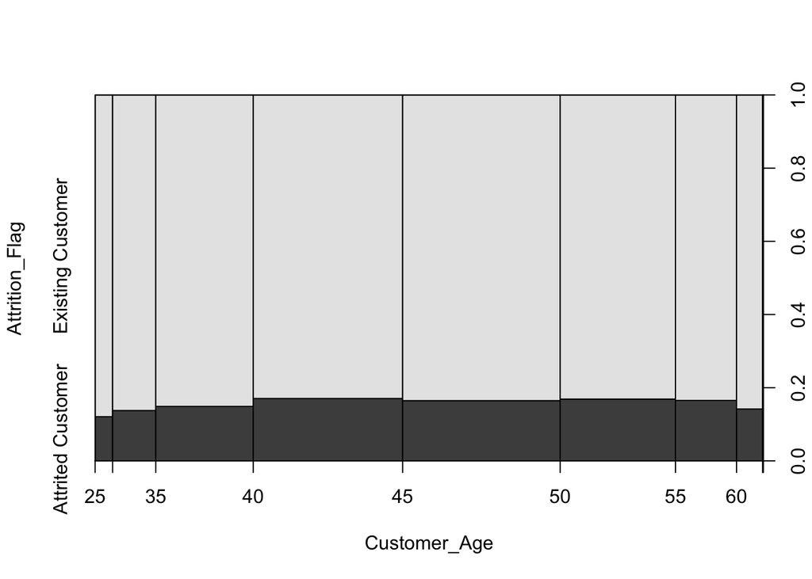

```r
plot(Attrition_Flag ~ Customer_Age, data = churn_data)
```

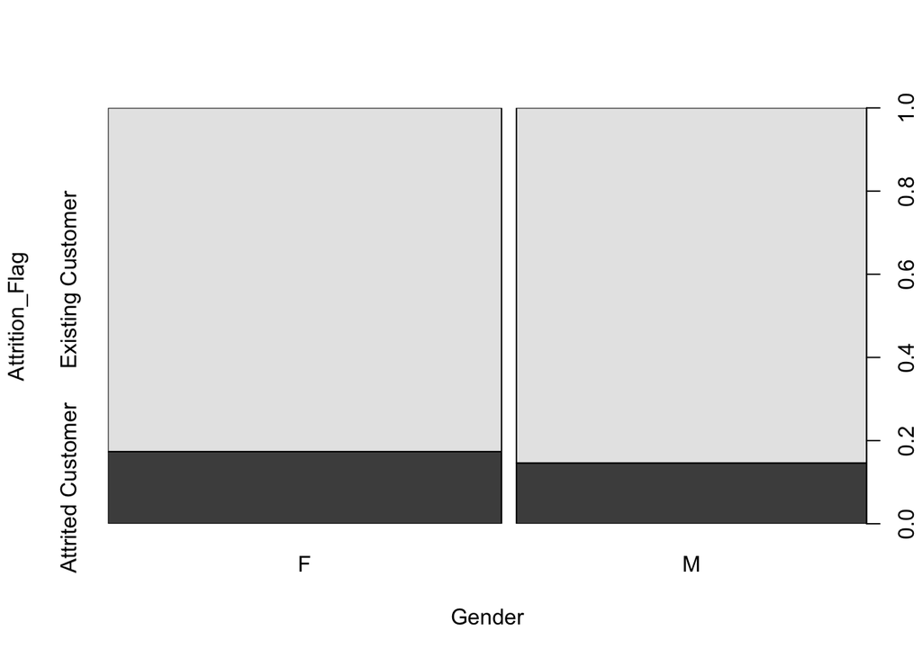

```r
plot(Attrition_Flag ~ Gender, data = churn_data)
```

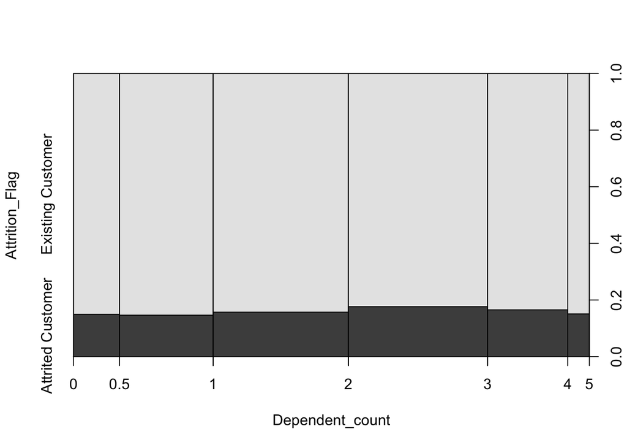

```r
plot(Attrition_Flag ~ Dependent_count, data = churn_data)
```

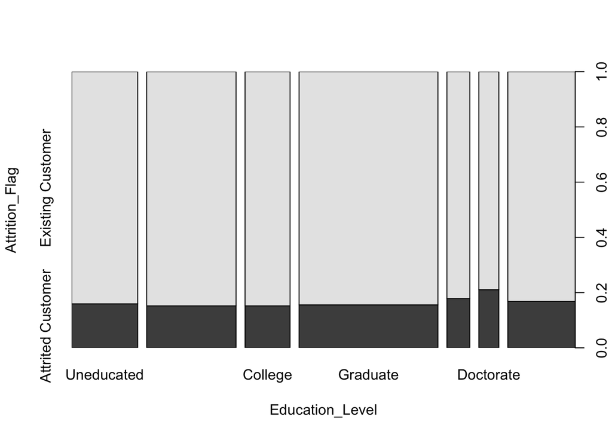

```r
plot(Attrition_Flag ~ Education_Level, data = churn_data)
```

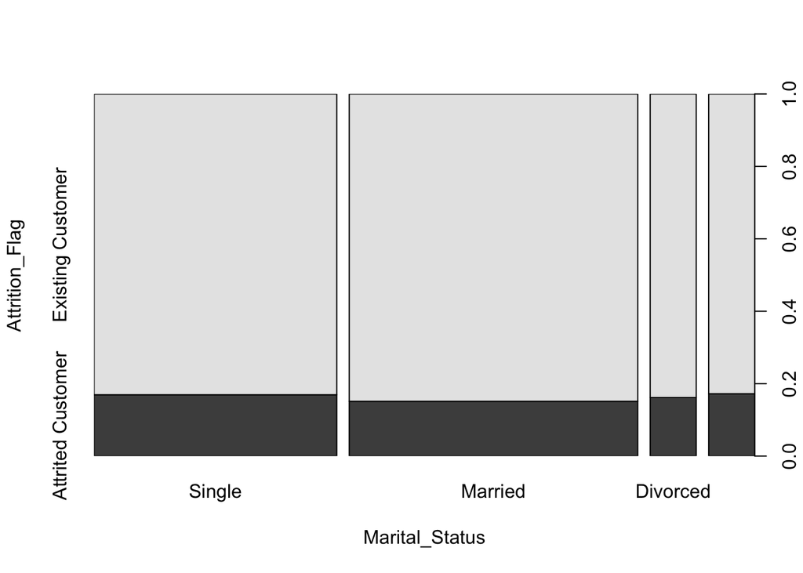

```r
plot(Attrition_Flag ~ Marital_Status, data = churn_data)
```

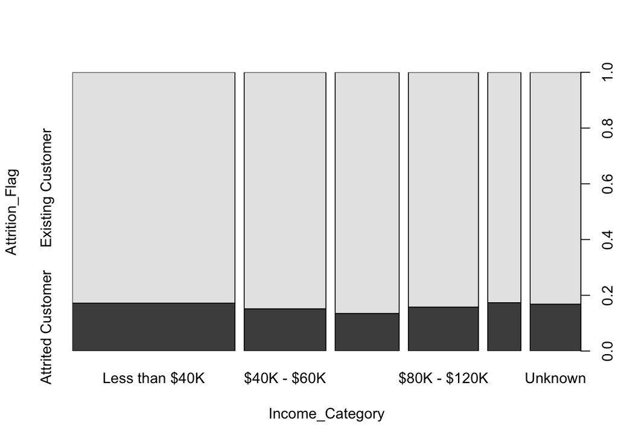

```r
plot(Attrition_Flag ~ Income_Category, data = churn_data)
```

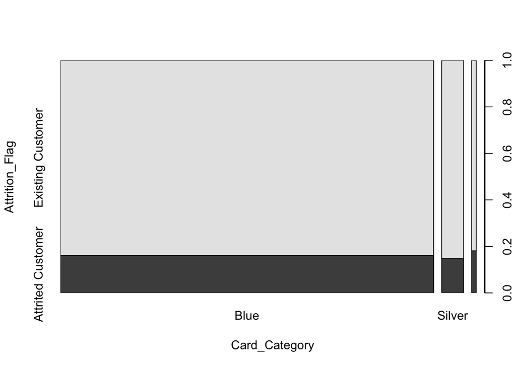

```r
plot(Attrition_Flag ~ Card_Category, data = churn_data)
```

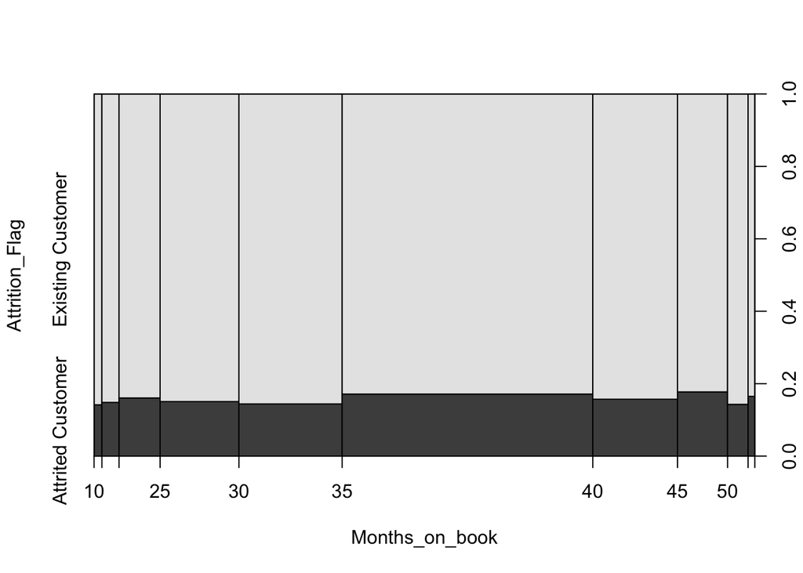

```r
plot(Attrition_Flag ~ Months_on_book, data = churn_data)
```

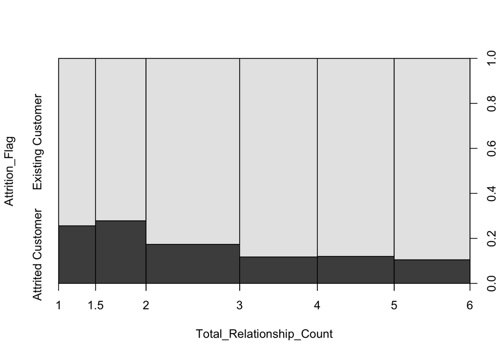

```r
plot(Attrition_Flag ~ Total_Relationship_Count, data = churn_data)
```

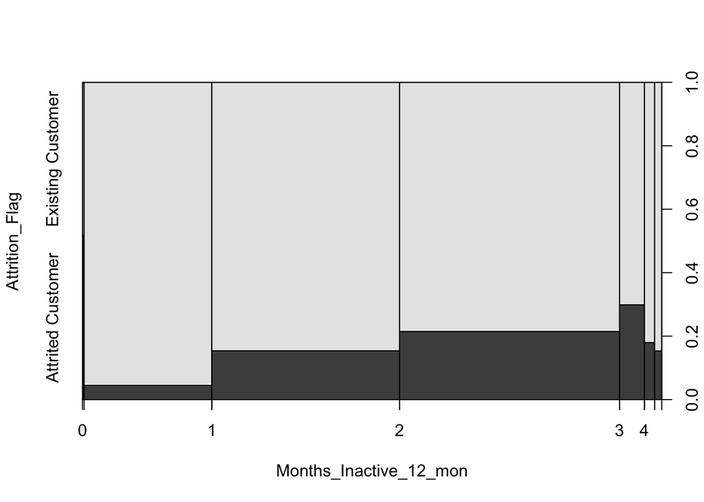

```r
plot(Attrition_Flag ~ Months_Inactive_12_mon, data = churn_data)
```

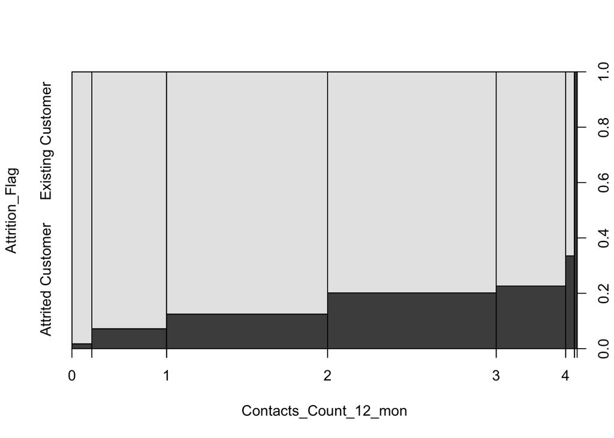

```r
plot(Attrition_Flag ~ Contacts_Count_12_mon, data = churn_data)
```

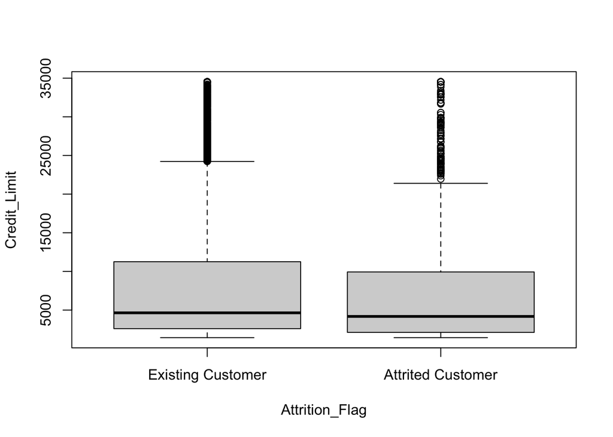

```r
plot(Credit_Limit ~ Attrition_Flag, data = churn_data)
```

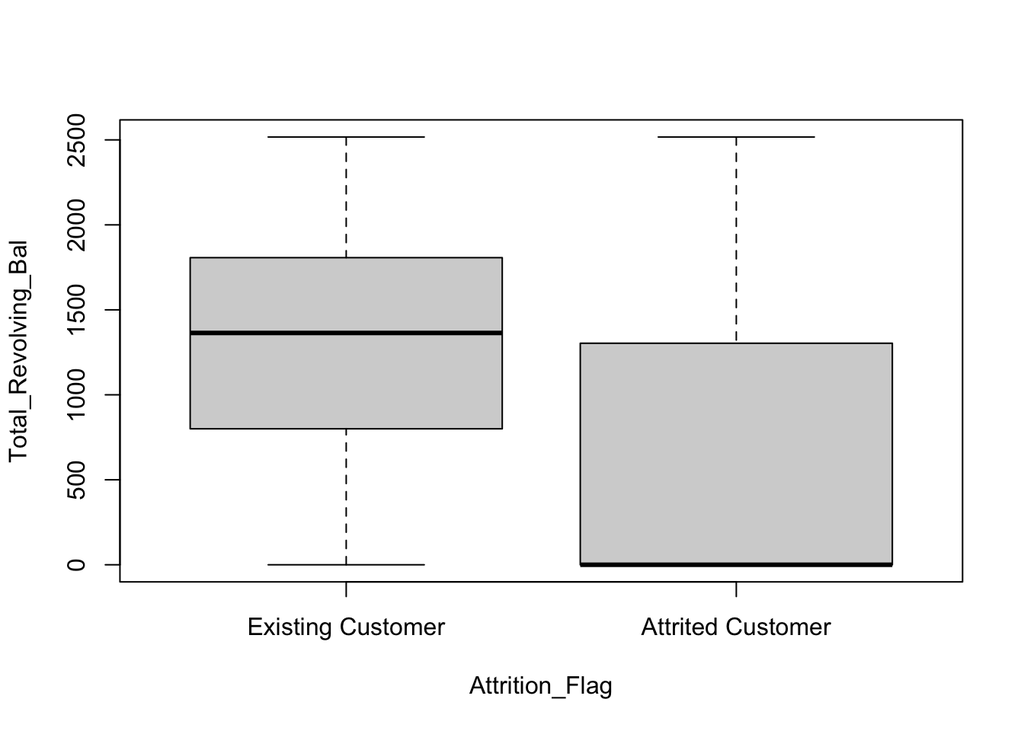

```r
plot(Total_Revolving_Bal ~ Attrition_Flag, data = churn_data)
```

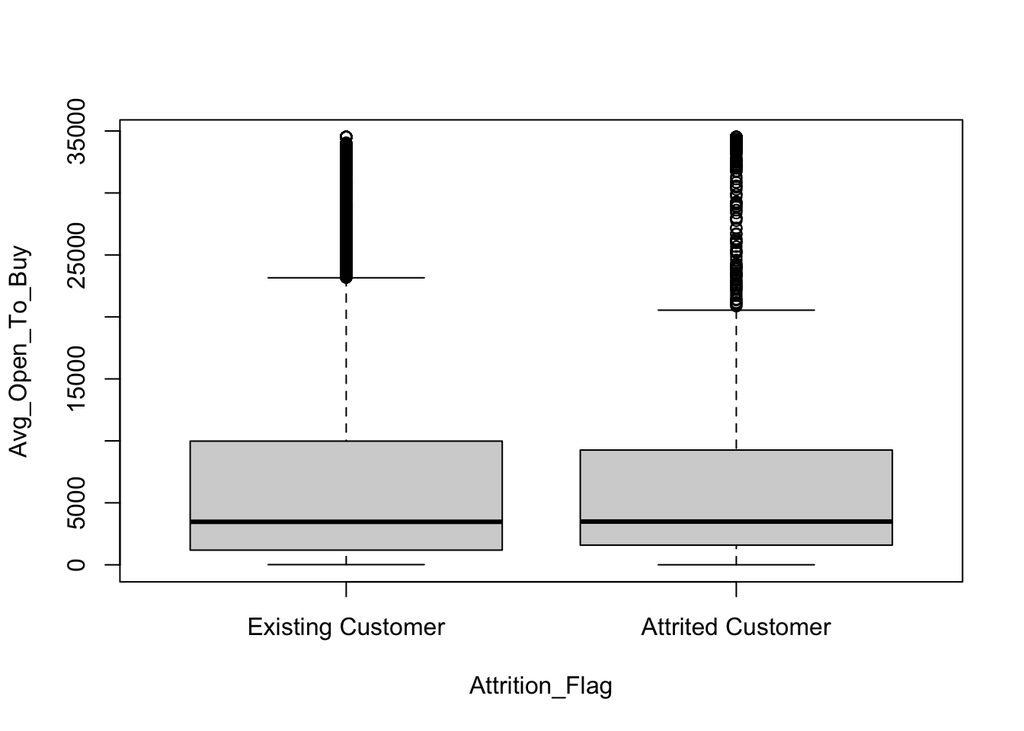

```r
plot(Avg_Open_To_Buy ~ Attrition_Flag, data = churn_data)
```

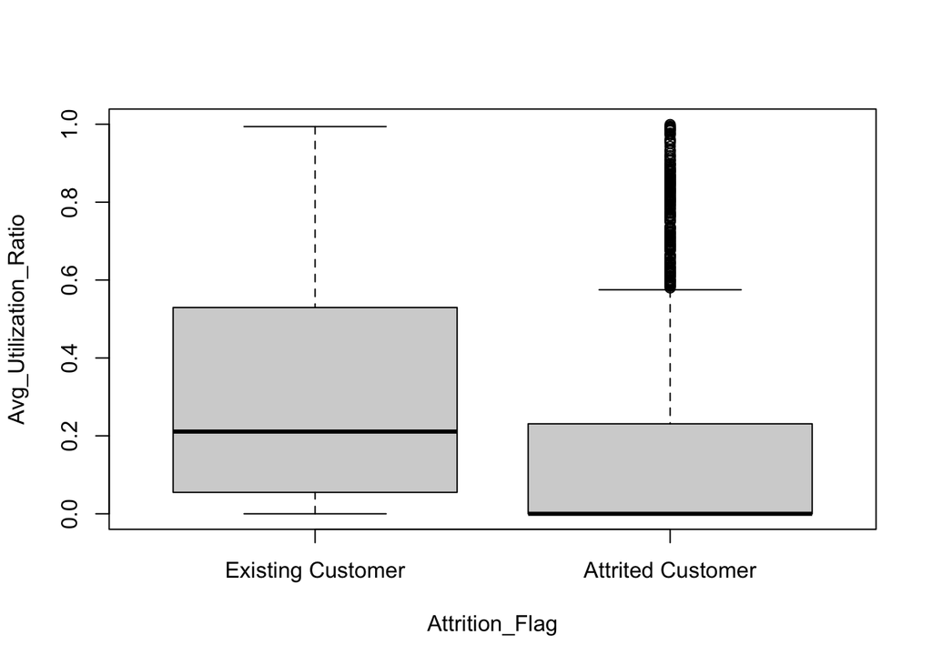

```r
plot(Avg_Utilization_Ratio ~ Attrition_Flag, data = churn_data)
```

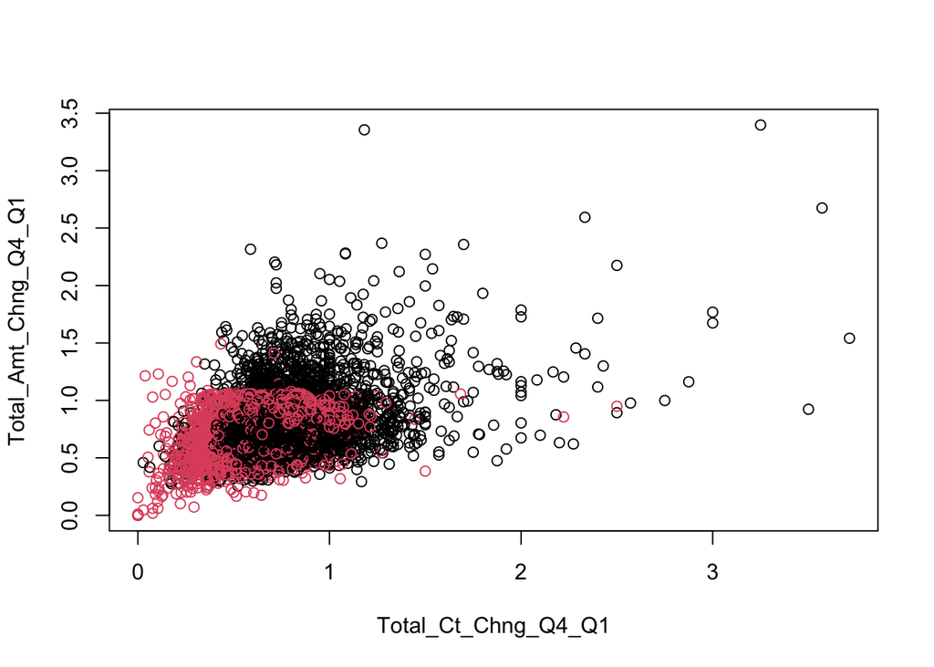

```r
plot(Total_Amt_Chng_Q4_Q1 ~ Total_Ct_Chng_Q4_Q1, col = as.numeric(Attrition_Flag), data = churn_data)
```

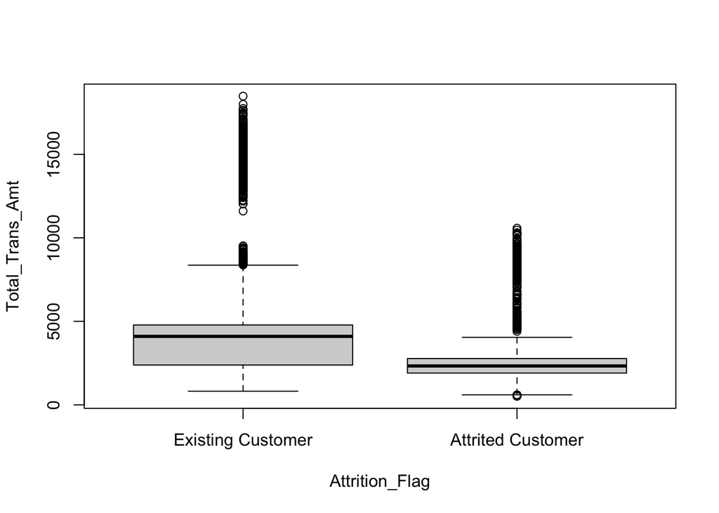

```r
plot(Total_Trans_Amt ~ Attrition_Flag, data = churn_data)
```

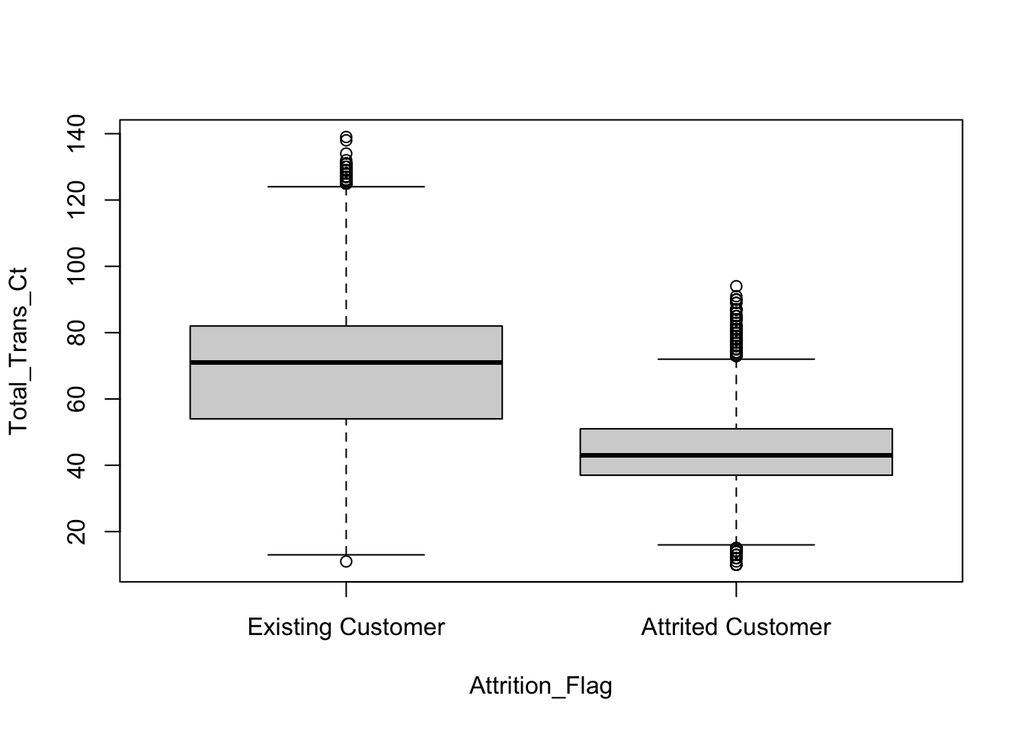

```r
plot(Total_Trans_Ct ~ Attrition_Flag, data = churn_data)
```

## Task 2

Splitting the data into training set and test set

```r
set.seed(123)
n <- nrow(churn_data)
n1 <- floor(0.8 * n)
train_sample <- sample(1:n, n1)

train_data <- churn_data[train_sample, ]
test_data  <- churn_data[-train_sample, ]
```

## Task 3

Estimating the logistic regression model with all variables: From the model, we can now identify whether a variable has a significant impact on churn based on the p-value.

Significant variables: GenderM, Dependent_count, Marital_StatusMarried, Income_Category80K - 120K, Income_Category120K +, Card_CategoryGold, Total_Relationship_Count, Months_Inactive_12_mon, Contacts_Count_12_mon, Credit_Limit, Total_Revolving_Bal, Total_Trans_Amt, Total_Trans_Ct and Total_Ct_Chng_Q4_Q1.

```r
logit_model <- glm(Attrition_Flag ~ ., data = train_data, family = binomial())
summary(logit_model)
```

```
##
## Call:
## glm(formula = Attrition_Flag ~ ., family = binomial(), data = train_data)
##
## Coefficients: (1 not defined because of singularities)
##                                Estimate Std. Error z value Pr(>|z|)
## (Intercept)                   6.244e+00  4.317e-01  14.466  < 2e-16 ***
## Customer_Age                 -6.225e-03  8.570e-03  -0.726  0.46762
## GenderM                      -9.767e-01  1.658e-01  -5.892 3.81e-09 ***
## Dependent_count               9.986e-02  3.366e-02   2.967  0.00301 **
## Education_LevelHigh School   -8.985e-02  1.460e-01  -0.615  0.53835
## Education_LevelCollege       -1.554e-01  1.747e-01  -0.890  0.37365
## Education_LevelGraduate      -1.838e-01  1.341e-01  -1.371  0.17033
## Education_LevelPost-Graduate  2.392e-01  2.120e-01   1.129  0.25909
## Education_LevelDoctorate      2.122e-01  2.232e-01   0.951  0.34159
## Education_LevelUnknown       -5.720e-03  1.534e-01  -0.037  0.97025
## Marital_StatusMarried        -6.892e-01  9.428e-02  -7.311 2.66e-13 ***
## Marital_StatusDivorced       -2.139e-01  1.754e-01  -1.220  0.22254
## Marital_StatusUnknown        -1.874e-01  1.630e-01  -1.150  0.25007
## Income_Category$40K - $60K   -1.328e-01  1.381e-01  -0.962  0.33630
## Income_Category$60K - $80K    2.019e-01  2.093e-01   0.965  0.33466
## Income_Category$80K - $120K   5.986e-01  2.119e-01   2.825  0.00472 **
## Income_Category$120K +        8.131e-01  2.478e-01   3.281  0.00103 **
## Income_CategoryUnknown       -1.041e-01  1.519e-01  -0.685  0.49326
## Card_CategorySilver           3.947e-01  2.196e-01   1.797  0.07229 .
## Card_CategoryGold             1.056e+00  3.855e-01   2.739  0.00616 **
## Card_CategoryPlatinum         1.031e+00  6.985e-01   1.476  0.13997
## Months_on_book               -4.352e-03  8.614e-03  -0.505  0.61343
## Total_Relationship_Count     -4.365e-01  3.055e-02 -14.290  < 2e-16 ***
## Months_Inactive_12_mon        5.018e-01  4.227e-02  11.871  < 2e-16 ***
## Contacts_Count_12_mon         5.095e-01  4.077e-02  12.498  < 2e-16 ***
## Credit_Limit                 -1.828e-05  7.565e-06  -2.416  0.01569 *
## Total_Revolving_Bal          -9.337e-04  8.030e-05 -11.628  < 2e-16 ***
## Avg_Open_To_Buy                      NA         NA      NA       NA
## Total_Amt_Chng_Q4_Q1         -4.067e-01  2.087e-01  -1.949  0.05129 .
## Total_Trans_Amt               4.929e-04  2.556e-05  19.281  < 2e-16 ***
## Total_Trans_Ct               -1.191e-01  4.168e-03 -28.579  < 2e-16 ***
## Total_Ct_Chng_Q4_Q1          -2.790e+00  2.119e-01 -13.169  < 2e-16 ***
## Avg_Utilization_Ratio        -9.317e-02  2.744e-01  -0.340  0.73416
## ---
## Signif. codes:  0 '***' 0.001 '**' 0.01 '*' 0.05 '.' 0.1 ' ' 1
##
## (Dispersion parameter for binomial family taken to be 1)
##
##     Null deviance: 7162.7  on 8100  degrees of freedom
## Residual deviance: 3790.0  on 8069  degrees of freedom
## AIC: 3854
##
## Number of Fisher Scoring iterations: 6
```

## Task 4

Performing the stepwise model selection using AIC:

The final model includes the following variables: Customer_Age, Gender, Dependent_count, Marital_Status, Income_Category, Card_Category, Total_Relationship_Count, Months_Inactive_12_mon, Contacts_Count_12_mon, Credit_Limit, Total_Revolving_Bal, Total_Amt_Chng_Q4_Q1, Total_Trans_Amt, Total_Trans_Ct, and Total_Ct_Chng_Q4_Q1.

```r
stepwise_model <- step(logit_model, direction = "both")
```

```
## Start:  AIC=3854.04
## Attrition_Flag ~ Customer_Age + Gender + Dependent_count + Education_Level +
##     Marital_Status + Income_Category + Card_Category + Months_on_book +
##     Total_Relationship_Count + Months_Inactive_12_mon + Contacts_Count_12_mon +
##     Credit_Limit + Total_Revolving_Bal + Avg_Open_To_Buy + Total_Amt_Chng_Q4_Q1 +
##     Total_Trans_Amt + Total_Trans_Ct + Total_Ct_Chng_Q4_Q1 +
##     Avg_Utilization_Ratio
##
##
## Step:  AIC=3854.04
## Attrition_Flag ~ Customer_Age + Gender + Dependent_count + Education_Level +
##     Marital_Status + Income_Category + Card_Category + Months_on_book +
##     Total_Relationship_Count + Months_Inactive_12_mon + Contacts_Count_12_mon +
##     Credit_Limit + Total_Revolving_Bal + Total_Amt_Chng_Q4_Q1 +
##     Total_Trans_Amt + Total_Trans_Ct + Total_Ct_Chng_Q4_Q1 +
##     Avg_Utilization_Ratio
##
##                            Df Deviance    AIC
## - Education_Level           6   3798.4 3850.4
## - Avg_Utilization_Ratio     1   3790.2 3852.2
## - Months_on_book            1   3790.3 3852.3
## - Customer_Age              1   3790.6 3852.6
## <none>                          3790.0 3854.0
## - Total_Amt_Chng_Q4_Q1      1   3793.9 3855.9
## - Card_Category             3   3799.9 3857.9
## - Credit_Limit              1   3795.9 3857.9
## - Dependent_count           1   3798.9 3860.9
## - Income_Category           5   3813.6 3867.6
## - Gender                    1   3827.0 3889.0
## - Marital_Status            3   3846.3 3904.3
## - Months_Inactive_12_mon    1   3932.8 3994.8
## - Total_Revolving_Bal       1   3933.8 3995.8
## - Contacts_Count_12_mon     1   3960.1 4022.1
## - Total_Ct_Chng_Q4_Q1       1   4010.1 4072.1
## - Total_Relationship_Count  1   4012.2 4074.2
## - Total_Trans_Amt           1   4151.1 4213.1
## - Total_Trans_Ct            1   4976.0 5038.0
##
## Step:  AIC=3850.4
## Attrition_Flag ~ Customer_Age + Gender + Dependent_count + Marital_Status +
```

[output cut: 66 more lines]

```
## + Avg_Utilization_Ratio     1   3798.8 3848.8
## + Education_Level           6   3790.4 3850.4
## - Card_Category             3   3808.8 3850.8
## - Credit_Limit              1   3805.2 3851.2
## - Dependent_count           1   3807.9 3853.9
## - Income_Category           5   3821.8 3859.8
## - Gender                    1   3836.0 3882.0
## - Marital_Status            3   3854.6 3896.6
## - Months_Inactive_12_mon    1   3940.3 3986.3
## - Contacts_Count_12_mon     1   3969.8 4015.8
## - Total_Ct_Chng_Q4_Q1       1   4019.6 4065.6
## - Total_Relationship_Count  1   4022.9 4068.9
## - Total_Trans_Amt           1   4162.4 4208.4
## - Total_Revolving_Bal       1   4182.4 4228.4
## - Total_Trans_Ct            1   4986.4 5032.4
```

```r
summary(stepwise_model)
```

```
##
## Call:
## glm(formula = Attrition_Flag ~ Customer_Age + Gender + Dependent_count +
##     Marital_Status + Income_Category + Card_Category + Total_Relationship_Count +
##     Months_Inactive_12_mon + Contacts_Count_12_mon + Credit_Limit +
##     Total_Revolving_Bal + Total_Amt_Chng_Q4_Q1 + Total_Trans_Amt +
##     Total_Trans_Ct + Total_Ct_Chng_Q4_Q1, family = binomial(),
##     data = train_data)
##
## Coefficients:
##                               Estimate Std. Error z value Pr(>|z|)
## (Intercept)                  6.146e+00  4.126e-01  14.897  < 2e-16 ***
## Customer_Age                -9.451e-03  5.224e-03  -1.809  0.07042 .
## GenderM                     -9.742e-01  1.651e-01  -5.901 3.61e-09 ***
## Dependent_count              1.004e-01  3.353e-02   2.995  0.00275 **
## Marital_StatusMarried       -6.845e-01  9.408e-02  -7.276 3.44e-13 ***
## Marital_StatusDivorced      -2.128e-01  1.752e-01  -1.214  0.22474
## Marital_StatusUnknown       -1.837e-01  1.626e-01  -1.130  0.25859
## Income_Category$40K - $60K  -1.254e-01  1.376e-01  -0.911  0.36213
## Income_Category$60K - $80K   2.162e-01  2.083e-01   1.038  0.29925
## Income_Category$80K - $120K  6.041e-01  2.108e-01   2.865  0.00417 **
## Income_Category$120K +       8.125e-01  2.471e-01   3.288  0.00101 **
## Income_CategoryUnknown      -8.172e-02  1.507e-01  -0.542  0.58754
## Card_CategorySilver          3.967e-01  2.193e-01   1.809  0.07049 .
## Card_CategoryGold            1.047e+00  3.857e-01   2.714  0.00664 **
## Card_CategoryPlatinum        1.095e+00  6.996e-01   1.566  0.11743
## Total_Relationship_Count    -4.378e-01  3.052e-02 -14.346  < 2e-16 ***
## Months_Inactive_12_mon       4.950e-01  4.188e-02  11.822  < 2e-16 ***
## Contacts_Count_12_mon        5.104e-01  4.075e-02  12.524  < 2e-16 ***
## Credit_Limit                -1.726e-05  6.923e-06  -2.494  0.01264 *
## Total_Revolving_Bal         -9.533e-04  5.131e-05 -18.580  < 2e-16 ***
## Total_Amt_Chng_Q4_Q1        -3.984e-01  2.082e-01  -1.914  0.05567 .
## Total_Trans_Amt              4.934e-04  2.545e-05  19.393  < 2e-16 ***
## Total_Trans_Ct              -1.189e-01  4.160e-03 -28.592  < 2e-16 ***
## Total_Ct_Chng_Q4_Q1         -2.789e+00  2.116e-01 -13.178  < 2e-16 ***
## ---
## Signif. codes:  0 '***' 0.001 '**' 0.01 '*' 0.05 '.' 0.1 ' ' 1
##
## (Dispersion parameter for binomial family taken to be 1)
##
##     Null deviance: 7162.7  on 8100  degrees of freedom
## Residual deviance: 3798.9  on 8077  degrees of freedom
## AIC: 3846.9
##
## Number of Fisher Scoring iterations: 6
```

```r
AIC(logit_model, stepwise_model)
```

|  | df | AIC |
| --- | --- | --- |
| logit_model | 32 | 3854.037 |
| stepwise_model | 24 | 3846.865 |

Each additional contact made with a costumer, changes the odds of churn by $e^{0.5104}$.

The odds change by $e^{1.095}$ if a customer has a Platinum card instead of a blue credit card.

## Task 5

Estimating the k-NN model with different k and doing the 5 fold cross validation

```r
knn_control <- trainControl(method = "cv", number = 5)

fit_knn <- train(Attrition_Flag ~ ., data=train_data, method="knn",
                 tuneGrid = data.frame(k=c(3, 5, 7, 9, 11, 13, 15)),
                 preProcess = "scale", trControl = knn_control)
```

The appropiate k-value is:

```r
print(fit_knn$bestTune[1, 1])
```

```
## [1] 5
```

The final knn model:

```r
model_knn <- knn3(Attrition_Flag ~. , data=train_data,k=fit_knn$bestTune[1,1])
print(model_knn)
```

```
## 5-nearest neighbor model
## Training set outcome distribution:
##
## Existing Customer Attrited Customer
##              6793              1308
```

## Task 6

Estimating the Naive Bayes model

```r
model_naivbay <- naiveBayes(Attrition_Flag~., data=train_data)
print(model_naivbay)
```

```
##
## Naive Bayes Classifier for Discrete Predictors
##
## Call:
## naiveBayes.default(x = X, y = Y, laplace = laplace)
##
## A-priori probabilities:
## Y
## Existing Customer Attrited Customer
##         0.8385385         0.1614615
##
## Conditional probabilities:
##                    Customer_Age
## Y                       [,1]     [,2]
##   Existing Customer 46.18534 8.106528
##   Attrited Customer 46.67813 7.755616
##
##                    Gender
## Y                           F         M
##   Existing Customer 0.5192110 0.4807890
##   Attrited Customer 0.5756881 0.4243119
##
##                    Dependent_count
## Y                       [,1]     [,2]
##   Existing Customer 2.338437 1.302289
##   Attrited Customer 2.353976 1.267904
##
##                    Education_Level
## Y                   Uneducated High School    College   Graduate Post-Graduate
##   Existing Customer 0.14853526  0.19799794 0.10083910 0.31238039    0.04916826
##   Attrited Customer 0.15137615  0.18577982 0.09633028 0.30045872    0.05733945
##                    Education_Level
## Y                    Doctorate    Unknown
##   Existing Customer 0.04195495 0.14912410
##   Attrited Customer 0.05428135 0.15443425
##
##                    Marital_Status
## Y                       Single    Married   Divorced    Unknown
##   Existing Customer 0.38142205 0.47033711 0.07478286 0.07345797
##   Attrited Customer 0.41896024 0.43042813 0.07186544 0.07874618
```

[output cut: 59 more lines]

```
##
##                    Total_Trans_Ct
## Y                       [,1]     [,2]
##   Existing Customer 68.59664 22.93777
##   Attrited Customer 45.08792 14.64241
##
##                    Total_Ct_Chng_Q4_Q1
## Y                        [,1]      [,2]
##   Existing Customer 0.7431029 0.2319711
##   Attrited Customer 0.5540023 0.2248926
##
##                    Avg_Utilization_Ratio
## Y                        [,1]      [,2]
##   Existing Customer 0.2967453 0.2726946
##   Attrited Customer 0.1612791 0.2659957
```

## Task 7

The most accurate model is the stepwise logistic regression model (pred_2). The model with the highest recall is the Naive Bayes model (pred_4). The model with the highest precision is the stepwise logistic regression model (pred_2).

For the bank, recall is the most suitable parameter for effectively identifying customers who are likely to churn. By prioritizing recall, the bank can ensure that it captures a higher proportion of actual churners, thereby minimizing the number of false negatives. This means that more customers who are at risk of leaving the bank will be accurately identified, allowing the institution to take proactive measures to retain them. Therefore the Naive Bayes model would be the best choice here, because it has the highest recall.

Prediction 1 (full logistic regression model):

```r
pred_1 <- predict(logit_model, newdata=test_data, type="response")
outcome_pred_1 <- as.numeric(pred_1 > 0.5)

table_1 <- table(predicted=outcome_pred_1, observed=test_data$Attrition_Flag)
print(table_1)
```

```
##          observed
## predicted Existing Customer Attrited Customer
##         0              1653               136
##         1                54               183
```

```r
accuracy_1 <- (table_1[1,1]+table_1[2,2])/(sum(table_1))
recall_1 <- table_1[2,2]/sum(table_1[,2])
precision_1 <- table_1[2,2]/sum(table_1[2,])
print(paste("Accuracy:", accuracy_1))
```

```
## [1] "Accuracy: 0.906219151036525"
```

```r
print(paste("Recall:", recall_1))
```

```
## [1] "Recall: 0.573667711598746"
```

```r
print(paste("Precision:", precision_1))
```

```
## [1] "Precision: 0.772151898734177"
```

Prediction 2 (stepwise logistic regression model):

```r
pred_2 <- predict(stepwise_model, newdata=test_data, type = "response")
outcome_pred_2 <- as.numeric(pred_2 > 0.5)

table_2 <-table(predicted=outcome_pred_2, observed=test_data$Attrition_Flag)
print(table_2)
```

```
##          observed
## predicted Existing Customer Attrited Customer
##         0              1656               136
##         1                51               183
```

```r
accuracy_2 <- (table_2[1,1]+table_2[2,2])/(sum(table_2))
recall_2 <- table_2[2,2]/sum(table_2[,2])
precision_2 <- table_2[2,2]/sum(table_2[2,])

print(paste("Accuracy:", accuracy_2))
```

```
## [1] "Accuracy: 0.907699901283317"
```

```r
print(paste("Recall:", recall_2))
```

```
## [1] "Recall: 0.573667711598746"
```

```r
print(paste("Precision:", precision_2))
```

```
## [1] "Precision: 0.782051282051282"
```

Prediction 3 (k-NN approach):

```r
pred_3 <- predict(fit_knn, newdata = test_data)
conf_matr_knn <- confusionMatrix(pred_3, test_data$Attrition_Flag, positive = "Attrited Customer")
print(conf_matr_knn)
```

```
## Confusion Matrix and Statistics
##
##                    Reference
## Prediction          Existing Customer Attrited Customer
##   Existing Customer              1675               209
##   Attrited Customer                32               110
##
##                Accuracy : 0.881
##                  95% CI : (0.8661, 0.8948)
##     No Information Rate : 0.8425
##     P-Value [Acc > NIR] : 4.907e-07
##
##                   Kappa : 0.4211
##
##  Mcnemar's Test P-Value : < 2.2e-16
##
##             Sensitivity : 0.34483
##             Specificity : 0.98125
##          Pos Pred Value : 0.77465
##          Neg Pred Value : 0.88907
##              Prevalence : 0.15745
##          Detection Rate : 0.05429
##    Detection Prevalence : 0.07009
##       Balanced Accuracy : 0.66304
##
##        'Positive' Class : Attrited Customer
##
```

Prediction 4 (Naive Bayes approach):

```r
pred_4 <- predict(model_naivbay, newdata = test_data)
conf_matr_naiv_bay <- confusionMatrix(pred_4, test_data$Attrition_Flag, positive = "Attrited Customer")
print(conf_matr_naiv_bay)
```

```
## Confusion Matrix and Statistics
##
##                    Reference
## Prediction          Existing Customer Attrited Customer
##   Existing Customer              1600               107
##   Attrited Customer               107               212
##
##                Accuracy : 0.8944
##                  95% CI : (0.8802, 0.9074)
##     No Information Rate : 0.8425
##     P-Value [Acc > NIR] : 1.034e-11
##
##                   Kappa : 0.6019
##
##  Mcnemar's Test P-Value : 1
##
##             Sensitivity : 0.6646
##             Specificity : 0.9373
##          Pos Pred Value : 0.6646
##          Neg Pred Value : 0.9373
##              Prevalence : 0.1575
##          Detection Rate : 0.1046
##    Detection Prevalence : 0.1575
##       Balanced Accuracy : 0.8009
##
##        'Positive' Class : Attrited Customer
##
```